# knearestneighbors

## The Euclidean Distance Formula

Let us assume we have the x, y coordinates of two places in a place and these are a = (2, -1) and b = (-2, 2). We would like to calculate the Euclidean distance between these two places.

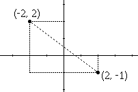

\begin{equation*} dist(2, -1), (-2, 2) = \sqrt{(2-(-2)^2) + ((-1)-2)^2} \end{equation*}\begin{equation*} = \sqrt{(2+2)^2 + (-1-2)^2} \end{equation*}\begin{equation*} = \sqrt{(4)^2 + (-3)^2} \end{equation*}\begin{equation*} = \sqrt{(16+9)^2} \end{equation*}\begin{equation*} = \sqrt{(25)} \end{equation*}

which would give us 5

Now that we understand how to formula works let us translate this formula to Python

```python
import numpy as np
import matplotlib.pyplot as plt
import pandas as pd
from sklearn import datasets
from collections import Counter
```

```python
data = datasets.load_iris()
data_data = data.data
data_labels = data.target
```

Now let's read our dataset. This time we are the Iris species dataset that we get from the sklearn library. We are going to skip the descriptive statistics and exploratory data analysis step and run straight run into building the knn algorithm from scratch. We are going to start off by splitting our data using the permutations function from np.random

```python
np.random.seed(42)
rand_indices = np.random.permutation(len(data_data))
n_training_samples = 12
training_data = data_data[rand_indices[:-n_training_samples]]
training_labels = data_labels[rand_indices[:-n_training_samples]]
test_data = data_data[rand_indices[-n_training_samples:]]
test_labels = data_labels[rand_indices[-n_training_samples:]]
```

Before we go further, let's remember what K means in K-NN. K represents the numbers of neighbors we need to use for the majority vote for our classification. A small value of k means that noise in the data will have a higher influence on the result while a large value might make the algorithm computationally expensive.

As a general rule of thumb we choose the value of that is the squareroot of N/2 where N is the number of samples in our training dataset. So:

\begin{equation*} k= \sqrt{\frac{N}{2}} \end{equation*}

More on choosing the value of K in knn: i. https://www.analyticsvidhya.com/blog/2018/03/introduction-k-neighbours-algorithm-clustering/

In our case this would translate to:

```python
def k_val(n):
    n = len(n) #get the length of x_train
    return int(round(np.sqrt(n/2))) #return number as integer, round off to the nearest whole number
```

```python
def eucl_distance(inst1,inst2):
    inst1 = np.array(inst1)
    inst2 = np.array(inst2)
    return np.linalg.norm(inst1-inst2)
```

The function np.linalg.norm is used to return one of eight different matrix norms or one of the vector norms Documentation: https://docs.scipy.org/doc/numpy/reference/generated/numpy.linalg.norm.html

The next step in the process is returning a list with 'k' neighbors that are closes to each instance in our test set.

```python
def get_neighbors(train,labels,test,k,dist):
    dists = []
    for i in range(len(train)):
        dist = dists(test, train[i])
        dists.append((train[i]. dist, labels[i]))
    dists.sort(key=lambda x: x[1])
    k_neighbors = dists[:k]
    return k_neighbors
```

Since KNN involves a majority vote process, we create a function using the Counter class from collections that will count the number of classes inside each of our lists containing the neighbors. We then return the most common class.

```python
def vote(neighbor):
    counter = Counter()
    for i in neighbor:
        counter[i[2]] +=1
    return counter.most_common(1)[0][0]

def vote(neighbors):
    class_counter = Counter()
    for neighbor in neighbors:
        class_counter[neighbor[2]] += 1
    return(class_counter.most_common(1)[0][0])
for i in range(n_training_samples):
    neighbors = get_neighbors(learnset_data,
                              learnset_labels,
                              testset_data[i],
                              3,
                              distance=distance)
    def vote_prob(neighbors):
        class_counter = Counter()
        for neighbor in neighbors:
            class_counter[neighbor[2]] += 1
        labels, votes = zip(*class_counter.most_common())
        winner = class_counter.most_common(1)[0][0]
        votes4winner = class_counter.most_common(1)[0][1]
        return(winner, votes4winner/sum(votes))
k = k_val(training_data)
for i in range(n_training_samples):
    neighbors = get_neighbors(training_data,
                              training_labels,
                              test_data[i],
                              k,
                              distance=distance
                             )
```